# Description du contexte

"Le jeu de données contenu dans data.csv décrit des candidatures au poste de chercheur d'or chez Orfée. L'objectif consiste à prédire le succès ou l'échec d'une candidature." Dans ce contexte, il faut distinguer les différents enjeux liés à la tâche. Le taux d'erreur nul (100% de succès) n’étant pas atteignable, il faut choisir quel type d'erreur doit être minimisé :

- Rejeter un bon candidat à tort (erreur de première espèce)
- ou recruter un mauvais candidat à tort (erreur de 2e espèce)

Ainsi nous pourrons opter pour un classifieur plus ou moins "optimiste" qui va systématiquement rejeter plus de candidats (à tort) mais acceptera des mauvais candidats avec un faible taux d'erreur ou inversement ou un classifeur équilibré entre les deux suivant le besoin. Pour cette raison il sera bon d'étudier non pas la justesse du modèle (accuracy) mais plutôt le taux de Précision et de Rappel. Il y aura nécessairement un trade-off à faire pour minimiser un typer d'erreur plutôt qu'un autre.

# Import des packages

Ci-dessous un liste des packages utilisés et necessaire dans ce notebook. Si certains packages ne sont pas installés sur votre machine, vous pouvez les installer en décommentant la cellule suivante

**Installation Packages manquants**

```python
# !pip install seaborn
```

**Packages utilisés**

```python
%matplotlib inline
# packages basiques pour l'analyse de données
import pandas as pd
import numpy as np

# packages graphiques
import matplotlib.pyplot as plt
import seaborn as sns

# packages pour la selection et l'optimasation du modèle
from sklearn.preprocessing import StandardScaler
from sklearn.decomposition import PCA
from sklearn.model_selection import train_test_split, GridSearchCV, StratifiedKFold, cross_val_score

# packages des classifieurs utilisés
from sklearn.ensemble import RandomForestClassifier, ExtraTreesClassifier
from sklearn.ensemble import GradientBoostingClassifier, AdaBoostClassifier, VotingClassifier
from sklearn.tree import DecisionTreeClassifier
from sklearn.neighbors import KNeighborsClassifier
from sklearn.naive_bayes import GaussianNB
from sklearn.discriminant_analysis import QuadraticDiscriminantAnalysis
from sklearn.linear_model import LogisticRegression
from sklearn.discriminant_analysis import LinearDiscriminantAnalysis
from sklearn.svm import SVC

# packages pour le scoring des modèles
from sklearn.metrics import recall_score, precision_score, precision_recall_curve
from sklearn.metrics import auc, confusion_matrix, make_scorer

# package pour l'analyse statistique
import scipy.stats as stats
from scipy.stats import chi2_contingency, pearsonr
import statsmodels.api as sm
from statsmodels.formula.api import ols

# packages utils
from sklearn.utils.fixes import signature
from sklearn.utils.multiclass import unique_labels
from sklearn.utils import compute_sample_weight
from collections import Counter
from sklearn.externals import joblib
import warnings
warnings.filterwarnings('ignore')
```

# Fonctions Utiles

```python
def plot_confusion_matrix(y_true, y_pred, classes,
                          normalize=False,
                          title=None,
                          cmap=plt.cm.Blues):
    """
    Cette fonction plot la matrice de confusion. Elle peut
    etre normalisée ou non avec le parametre 'normalize = True'
    """
    if not title:
        if normalize:
            title = 'Normalized confusion matrix'
        else:
            title = 'Confusion matrix, without normalization'

    # Compute confusion matrix
    cm = confusion_matrix(y_true, y_pred)
    # Only use the labels that appear in the data
    if normalize:
        cm = cm.astype('float') / cm.sum(axis=1)[:, np.newaxis]

    fig, ax = plt.subplots()
    im = ax.imshow(cm, interpolation='nearest', cmap=cmap)
    ax.figure.colorbar(im, ax=ax)
    # We want to show all ticks...
    ax.set(xticks=np.arange(cm.shape[1]),
           yticks=np.arange(cm.shape[0]),
           # ... and label them with the respective list entries
           xticklabels=classes, yticklabels=classes,
           title=f'{title} Matrice de confusion',
           ylabel='True label',
           xlabel='Predicted label')

    # Rotate the tick labels and set their alignment.
    plt.setp(ax.get_xticklabels(), rotation=45, ha="right",
             rotation_mode="anchor")

    # Loop over data dimensions and create text annotations.
    fmt = '.2f' if normalize else 'd'
    thresh = cm.max() / 2.
    for i in range(cm.shape[0]):
        for j in range(cm.shape[1]):
            ax.text(j, i, format(cm[i, j], fmt),
                    ha="center", va="center",
                    color="white" if cm[i, j] > thresh else "black")
    fig.tight_layout()
    return ax

def plot_prauc(model_list, y_test, X_test, pos_label=1, clf_name=None, weight='balanced', figsize=(8,6)):
    """
    Cette fonction plot la courbe de Precision-Recall
    (Recall en absisse et Presision en ordonnees)
    Ainsi que l'aire sous la courbe.
    """
    plt.figure(figsize=figsize)
    for i, model in enumerate(model_list):
        sw = compute_sample_weight(class_weight=weight, y=y_test)
        y_pred_pb = model.predict_proba(X_test)
        precision, recall, _ = precision_recall_curve(sample_weight=sw,
                                                      y_true=y_test, probas_pred=y_pred_pb[:, 1],
                                                      pos_label=pos_label)
        area = auc(x=recall, y=precision)
        model_name = clf_name[i]
        print(f'{model_name} : AUC = {area:.3f}')
        plt.plot(recall, precision, marker=',', label=model_name, )
        plt.title('Courbe de Precision-Recall')
        plt.xlabel('Recall')
        plt.ylabel('Precision')
        plt.ylim(0.5,1.01)
        plt.legend()
    plt.plot([0, 1], [1,min(precision)], linestyle='--')
    plt.draw()
    return

def prauc_score(y_test, y_pred, weight='balanced'):
    """
    Cette fonction renvoi le score d'aire
    sous la courbe Precision-Recall
    """
    sw = compute_sample_weight(class_weight=weight, y=y_test)
    precision, recall, _ = precision_recall_curve(sample_weight=sw, y_true=y_test,
                                                  probas_pred=y_pred, pos_label=1)
    area = auc(x=recall, y=precision)
    return area
```

# Exploration des données

Une première approche du jeu de données nous permet de visualiser le type de données auxquels nous avons à faire. On constate 20.000 observations. Des types de données différents :

- Catégorielles (cheveux, sexe, diplôme, spécialité, dispo)
- Numériques continues (salaire, note)
- Numériques discrètes (âge, expérience)
- Format date (date)

Certaines données sont manquantes, on peut voir l'apparition de NaN. Cela peut poser problème par la suite, il faudra pouvoir les corriger. Il est intéressant aussi de constater que le jeu de données est très déséquilibré : il n'y a que 11,5% de cas positifs.

**Choix de la métrique d’évalutation :** Dans ce cas particulier il faudra choisir une méthode de scoring qui prenne en compte un tel déséquilibre. Une bonne métrique dans ce cas est l'aire sous la courbe de Precision-Recall (rappel en abscisse et précision en ordonnées) qui est plus appropriée que la courbe ROC. C’est celle-là que nous choisirons.

```python
# Importation du dataframe:
df = pd.read_csv("data_v1.0.csv", delimiter=',', usecols=range(2, 13))

# Transformation de la date au format date_time pour pouvoir l'exploiter par la suite:
df['date'] = pd.to_datetime(df.date)
print(df.head())
print(),print()
print(df.info())

# Données quantitatives :
print(df.describe())
print(),print()
# Données qualitatives :
print(df.describe(include=['O']))
print(),print()
# Valeurs uniques :
print(df.nunique())
```

```
        date cheveux   age   exp  salaire sexe  diplome specialite   note  \
0 2012-06-02    roux  25.0   9.0  26803.0    F  licence   geologie  97.08
1 2011-04-21   blond  35.0  13.0  38166.0    M  licence     forage  63.86
2 2012-09-07   blond  29.0  13.0  35207.0    M  licence   geologie  78.50
3 2011-07-01    brun   NaN  12.0  32442.0    M  licence   geologie  45.09
4 2012-08-07    roux  35.0   6.0  28533.0    F  licence  detective  81.91

  dispo  embauche
0   non         0
1   non         0
2   non         0
3   non         0
4   non         0


<class 'pandas.core.frame.DataFrame'>
RangeIndex: 20000 entries, 0 to 19999
Data columns (total 11 columns):
date          19909 non-null datetime64[ns]
cheveux       19897 non-null object
age           19909 non-null float64
exp           19904 non-null float64
salaire       19905 non-null float64
sexe          19900 non-null object
diplome       19890 non-null object
specialite    19907 non-null object
note          19886 non-null float64
dispo         19894 non-null object
embauche      20000 non-null int64
dtypes: datetime64[ns](1), float64(4), int64(1), object(5)
memory usage: 1.7+ MB
None
                age           exp       salaire          note      embauche
count  19909.000000  19904.000000  19905.000000  19886.000000  20000.000000
mean      35.004521      9.500352  34974.343934     75.168762      0.114600
std        9.609169      3.012109   5003.099616     17.095926      0.318547
min       -3.000000     -2.000000  14128.000000      8.680000      0.000000
25%       29.000000      7.000000  31596.000000     63.720000      0.000000
50%       35.000000      9.000000  34979.000000     75.080000      0.000000
75%       41.000000     12.000000  38358.000000     86.617500      0.000000
max       74.000000     23.000000  53977.000000    143.220000      1.000000


        cheveux   sexe diplome specialite  dispo
count     19897  19900   19890      19907  19894
unique        4      2       4          4      2
top     chatain      M  master   geologie    non
freq       6022  11889    7513      10028  11848


date           1826
cheveux           4
age              76
exp              25
salaire       12326
sexe              2
diplome           4
specialite        4
note           6679
dispo             2
embauche          2
dtype: int64
```

# Distribution des données

## Données Quantitatives

A l'observation de la distribution des données quantitatives on constate que les données semblent gaussiennes. Néanmoins on peut voir un pic au niveau de l’âge autour de la valeur 35 ans qui pourrait contredire cette hypothèse. La distribution normale des données est souvent une hypothèse préalable à d'autres tests que nous réaliserons par la suite, notamment pour l'analyse de la variance (ANOVA). Pour appuyer cette hypothèse, nous pouvons tracer un QQ-plot qui permet une visualisation simple et rapide de la normalité. Néanmoins il ne s'agit pas d'un test fiable. Pour cette raison nous procèderons à un test de normalité des variables. Certaines variables n'étant pas continues, nous utiliserons le test de "scipy.stats.normaltest" qui est basé sur la méthode D'Agostino et Pearson qui permet de tester la normalité dans le cas de variables discrètes contrairement à un test de Shapiro-Wilk ou Jarque-Bera par exemple.

**H0**: Les variables proviennent d’une loi normale :

- si la p-value est inférieure au risque alpha de 5%, alors l'hypothèse nulle est rejetée.
- si la p-value est supérieure au risque alpha de 5%, alors on ne doit pas rejeter l'hypothèse nulle

Au regard des p-value nous conclurons que les variables proviennent bien d'une loi normale, sauf pour la variable (âge).

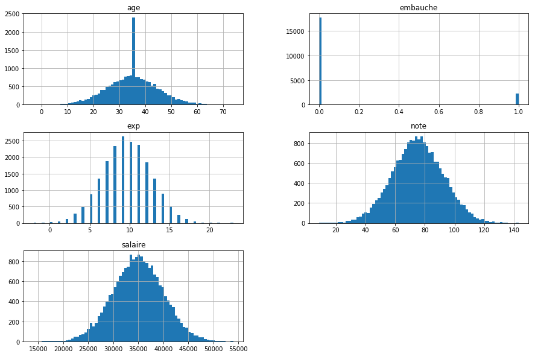

```
Variable note : p-value = 0.8230 > 0.05, on accepte l'hypothèse de normalité
Variable salaire : p-value = 0.9496 > 0.05, on accepte l'hypothèse de normalité
Variable age : p-value = 0.0005 << 0.05, on rejette l'hypothèse de normalité
Variable exp : p-value = 0.2642 > 0.05, on accepte l'hypothèse de normalité
```

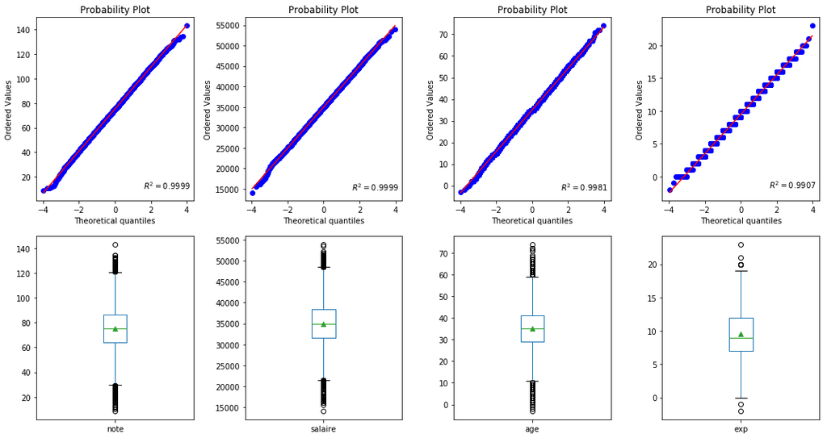

```python
# Répartition des données Quantitatives :
df.hist(figsize=(15,10), bins=75)
plt.show()

# Boites à moustache et QQ-plot :
quantitatives = ['note','salaire','age','exp']
fig, ax = plt.subplots(ncols=4, nrows=2,  figsize=(15,8))
for i, feat in enumerate(quantitatives):
    stats.probplot(df[feat].dropna(), dist="norm", rvalue=True, plot=ax[0,i])
    df[feat].plot(kind='box', showmeans=True, ax=ax[1,i])
plt.tight_layout()

# Test de normalité des variables quantitatives
for feat in quantitatives:
    k2, p = stats.normaltest(df[[feat]], nan_policy='omit')
    if p<0.05:
        print(f"Variable {feat} : p-value = {p[0]:.4f} << 0.05, on rejette l'hypothèse de normalité")
    else :
        print(f"Variable {feat} : p-value = {p[0]:.4f} > 0.05, on accepte l'hypothèse de normalité")
```

## Données Qualitatives

En observant la réparation des données qualitatives, nous remarquons que les données sont déséquilibrées avec notamment une fréquence nettement inférieure pour les classes : "roux" (cheveux), "F" (sexe), "bac" et "doctorat" (diplôme), "oui" (dispo) et une très faible fréquence de la classe "archéologie" en comparaison à la classe "géologie" (spécialité). On observe aussi un déséquilibre dans la proportion d'embauche de ces classes, particulièrement élevé dans les catégories (spécialité) et (diplôme). Avec une surreprésentation de la classe "archéologie" à plus de 20% contre une moyenne de 10% pour les autres classes. Et une surreprésentation des classes "master" et "licence" à 12% contre 8% en moyenne pour les autres.

> Ces écarts observés serviront à apporter plus d'informations pour entrainer le modèle, notamment en créant un ranking des classes par catégorie.

```
Répartition des données qualitatives:
```

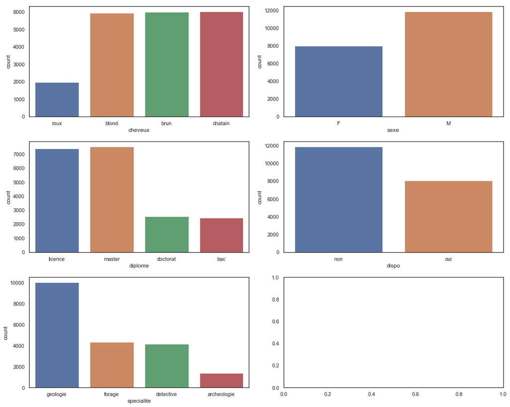

```python
# Répartition des données qualitatives:
print('Répartition des données qualitatives:')
sns.set(font_scale=1, style='white')
_, ax = plt.subplots(nrows=3, ncols=2, figsize=(15,12))
sns.countplot(data=df, x='cheveux', ax=ax[0,0])
sns.countplot(data=df, x='sexe', ax=ax[0,1])
sns.countplot(data=df, x='diplome', ax=ax[1,0])
sns.countplot(data=df, x='dispo', ax=ax[1,1])
sns.countplot(data=df, x='specialite', ax=ax[2,0])
plt.tight_layout()
```

```
Proportion d'embauche par catégorie:
```

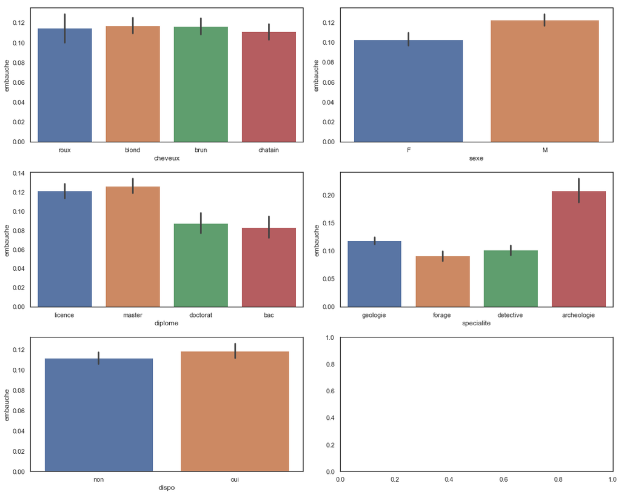

```python
# proportion d'embauche par catégorie :
print('Proportion d\'embauche par catégorie:')
sns.set(font_scale=1, style='white')
_, ax = plt.subplots(nrows=3, ncols=2, figsize=(15,12), sharey=False)
sns.barplot(x="cheveux",y="embauche",data=df, ax=ax[0,0])
sns.barplot(x="sexe",y="embauche",data=df, ax=ax[0,1])
sns.barplot(x="diplome",y="embauche",data=df, ax=ax[1,0])
sns.barplot(x="specialite",y="embauche",data=df, ax=ax[1,1])
sns.barplot(x="dispo",y="embauche",data=df, ax=ax[2,0])
plt.tight_layout()
```

## Données Temporelles

Après un retraitement de la variable (date) pour la séparer en "année", "mois" et "jour", nous observons comme pour les données qualitatives un déséquilibre dans la proportion d'embauche. On observe par exemple que la proportion d'embauche est plus élevée en 2013 que les autres années ou plus faible au mois de février que les autres mois.

> De même, ces écarts observés serviront à apporter plus d'informations pour entrainer le modèle.

```
Proportion d'embauche par annee, mois et jour:
```

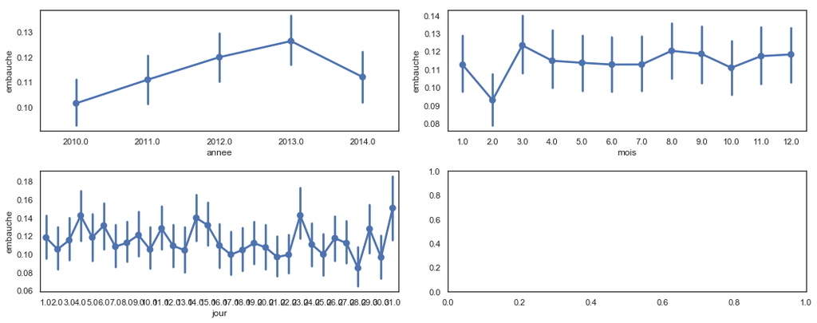

```python
# Traitement de la date et création des features "annee", "mois" et "jour":
df.insert(loc=1, value=df['date'].dt.year, column='annee')
df.insert(loc=2, value=df['date'].dt.month, column='mois')
df.insert(loc=3, value=df['date'].dt.day, column='jour')
df.drop(columns='date', inplace=True)

# proportion d'embauche par annee, mois et jour:
print('Proportion d\'embauche par annee, mois et jour:')
_, ax = plt.subplots(nrows=2, ncols=2, figsize=(15,6))
sns.pointplot(x='annee', y='embauche', data=df, ax=ax[0,0])
sns.pointplot(x='mois', y='embauche', data=df, ax=ax[0,1])
sns.pointplot(x='jour', y='embauche', data=df, ax=ax[1,0])
plt.tight_layout()
```

## Traitement des outliers

Dans le jeu de données nous observons des valeurs aberrantes, comme notamment des âges et des expériences qui prennent des valeurs négatives. Cependant comme il s'agit d'un exercice, il ne faut pas chercher de véritable cohérence avec un cas concret. Ici nous avons des données normalement distribuées et les outliers correspondent aux queux d'une loi normale. Les supprimer enlèverait de l'information au modèle. Pour cette raison j'ai considéré qu'il valait mieux les conserver. Néanmoins, si l'on voulait traiter un cas réel, on pourrait appliquer la méthode de Tukey qui supprime les valeurs situées en dehors de 1,5 fois l'intervalle interquartile. C'est ce que fait la fonction "detect_outliers" ci-dessous:

```python
# def detect_outliers(df,n,features):
#     """
#     Prend les variables d'un dataframe et renvoie une liste
#     des index correspondant aux observations contenant plus de n
#     valeurs aberrantes selon la méthode de Tukey.
#     """
#     outlier_indices = []
#     # iterate over features(columns)
#     for col in features:
#         # 1st quartile (25%)
#         Q1 = np.nanpercentile(df[col], 25)
#         # 3rd quartile (75%)
#         Q3 = np.nanpercentile(df[col],75)
#         # Interquartile range (IQR)
#         IQR = Q3 - Q1
#         # outlier step
#         outlier_step = 1.5*IQR
#         # Determine a list of indices of outliers for feature col
#         outlier_list_col = df[(df[col] < Q1 - outlier_step) | (df[col] > Q3 + outlier_step )].index
#         # append the found outlier indices for col to the list of outlier indices
#         outlier_indices.extend(outlier_list_col)
#     # select observations containing more than 2 outliers
#     outlier_indices = Counter(outlier_indices)
#     multiple_outliers = list( k for k, v in outlier_indices.items() if v >= n )
#     return multiple_outliers
```

```python
# # Suppression des Outliers avec au moins 1 outlier par ligne:
# tmp = df.copy()
# Outliers_to_drop = detect_outliers(tmp,1,["age","note","exp","salaire"])
# tmp.drop(index=tmp.loc[Outliers_to_drop].index, inplace=True)
# tmp.reset_index(inplace=True, drop=True)
# print(f'Nombre outliers supprimés : {len(Outliers_to_drop)}')
# del tmp
```

# Analyse bivariée

Pour traiter de la dépendance des variables deux à deux, nous avons pu vérifier l'hypothèse que les données quantitatives (à l'exception de l’âge) suivaient une distribution Gaussienne. Pour pouvoir appliquer des tests par intervalle de confiance il faudrait en toute rigueur vérifier aussi l'homoscédasticité et l'indépendance des observations que nous ne traiterons pas ici.

## Quantitative vs Quantitatives : Test de corrélation de Pearson

Pour la dépendance de variables quantitative nous utilisons un test de corrélation de Pearson.

**H0** : La corrélation entre les deux variables vaut zéro. On rejettera l’hypothèse si la p-value est inférieure au risque alpha de 5%.

Observations des variables deux à deux :

- Le premier constat que l'on fait graphiquement en voyant les Pairplots est que la note et le salaire décrivent un ovale. Nous voudrons donc tester le degré de corrélation de ces variables.
- Ensuite on constate que la distribution des données est la même pour les observations positives (jaune) et pour les observations négatives (bleu). Il n'est donc pas possible d'établir un critère de distinction par simple observation des variables unes à unes.
- Enfin on remarque que les observations positives et négatives sont concentriques et les positives ont un écart-type plus resserrées que les négatives. Pour cette raison et afin de mieux séparer les observations, on va vouloir projeter les donner dans un nouvel espace qui maximise la variance à l'aide d'une PCA.

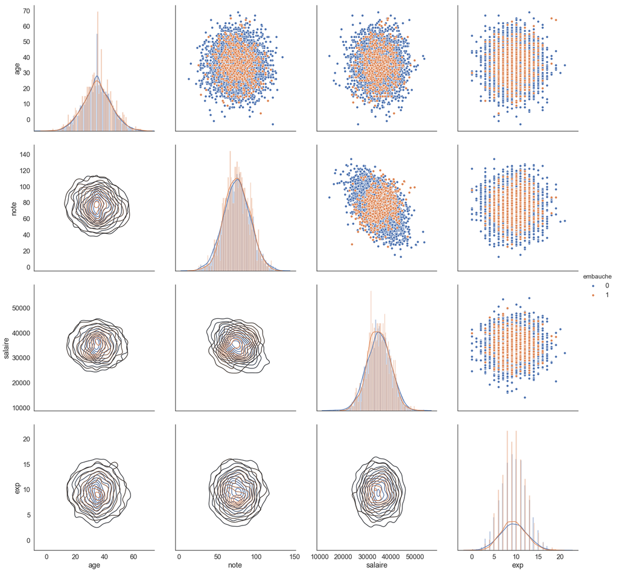

```python
sns.set(font_scale=1.5, style='white')
g = sns.PairGrid(df.iloc[:5000,:].dropna(), vars=['age', 'note', 'salaire', 'exp'],
                 hue='embauche', height=5, diag_sharey=False)
g = g.map_diag(sns.distplot, bins=75)
g = g.map_lower(sns.kdeplot)
g = g.map_upper(sns.scatterplot)
g.add_legend()
plt.show()
```

### Expérience vs Note

Ici nous souhaitons vérifier s'il existe une corrélation entre la variable (exp) et la variable (note). Le coefficient de corrélation est proche de zéro avec une p-value > 5%. On ne peut donc pas rejeter l'hypothèse à 95% que le coefficient de corrélation soit nul. Les deux variables n'ont pas de dépendance significative.

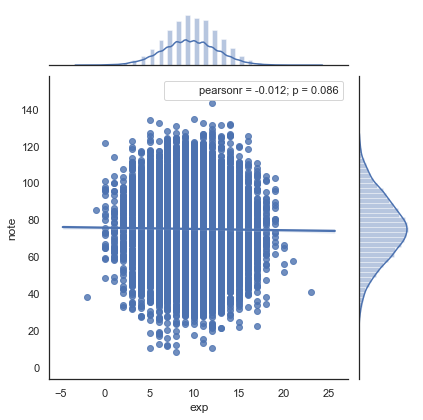

```python
# Pairplot note vs exp :
sns.set(font_scale=1, style='white')
sns.jointplot(x="exp", y="note", data=df, kind="reg", height=6).annotate(stats.pearsonr)
plt.show()
```

### Dépendance des variables deux à deux

Grâce à la matrice des corrélations nous pouvons constater, comme cela a été mentionné précédemment, une corrélation entre les variables (note) et (salaire). Il y a effectivement une corrélation négative modérée que l'on ne peut pas rejeter (coef. corr = -0.45). Mais cette corrélation n'est pas suffisamment significative pour pouvoir être exploité. Nous pouvons aussi constater que la corrélation n'est pas la même en fonction de la sous-population. Tandis que la demande de salaire à tendance à baisser plus la note est élevée pour les labels négatifs, l'effet inverse est observé pour les labels positifs.

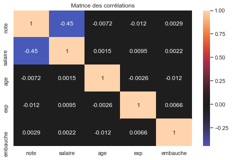

```python
sns.set(font_scale=1, style='white')
plt.figure(figsize=(8,5))
ax = plt.axes()
ax.set_title('Matrice des corrélations')
sns.heatmap(df[np.hstack([quantitatives, 'embauche'])].corr(),annot=True, center=0, ax=ax)
plt.show()
```

```python
# Création d'une matrice récapitulative des dépendances que l'on retrouvera dans la section associée :
tmp = df.dropna()
tab_dep = pd.DataFrame(columns=df.columns, index=df.columns)
for i in tab_dep.columns:
    tab_dep.loc[i,i] = 0
for feat1 in np.array(quantitatives):
    for feat2 in np.array(quantitatives):
        _, pval = pearsonr(x=tmp[feat1], y=tmp[feat2])
        tab_dep.loc[feat1,feat2] = f'{pval:.2f}'
        tab_dep.loc[feat2,feat1] = f'{pval:.2f}'
del tmp
```

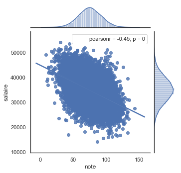

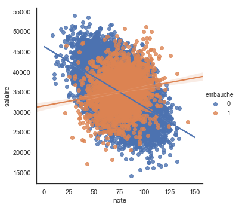

```python
# Pairplot et régression linéaire salaire vs note
sns.jointplot(x="note", y="salaire", data=df, kind="reg", height=5).annotate(stats.pearsonr)
sns.lmplot(x="note", y="salaire", data=df, hue='embauche', height=5)
plt.show()
```

## Qualitative vs Qualitative : Table de contingence et test du Chi2

Pour mesurer la dépendance de deux variables qualitatives, on procède généralement avec un test du Chi2 effectué sur la table de contingence des deux variables à tester. Pour effectuer ce test, la fonction "cat_dependance" (cf. notebook) qui fait appelle au module chi2_contengency de Scipy, renvoie la valeur du Chi2, la p-value, les degrés de liberté, la matrice de contingence et la matrice des écarts pondérés.

**H0** : Les variables sont indépendantes. On rejettera cette hypothèse avec un risque alpha à 5% si la p-value < 0.05

```python
def cat_dependance(df, feat1, feat2, showimg=True):
    contingence = pd.crosstab(columns=df[feat2], index=df[feat1], normalize=False, margins=True, dropna=True)
    chi2, p, dof, expected = chi2_contingency(contingence)
    expected = pd.DataFrame(expected, columns=contingence.columns, index=contingence.index)
    ecarts_pond = ((contingence-expected)/expected).iloc[:-1,:-1]
    if showimg :
        print('Table de contingence : ')
        print('-'*40)
        print(contingence)
        print('-'*40)
        ax = plt.axes()
        sns.heatmap(ecarts_pond, annot=True, center=0)
        ax.set_title('Ecarts pondérés')
        print(f'p-value test chi2 : {p}')
        if p < 0.05:
            print('p < 0.05, on rejette l\'hypothèse d\'indépendance des variables\n')
        else :
            print('p > 0.05, les variables sont indépendantes\n')

    return chi2, p, dof, expected, contingence, ecarts_pond
```

### Spécialité vs Sexe

```
Table de contingence :
----------------------------------------
sexe            F      M    All
specialite
archeologie  1081    298   1379
detective    2522   1614   4136
forage       1964   2351   4315
geologie     2403   7576   9979
All          7970  11839  19809
----------------------------------------
p-value test chi2 : 0.0
p < 0.05, on rejette l'hypothèse d'indépendance des variables
```

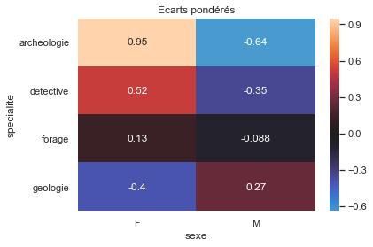

```python
chi2, p, dof, expected, cont, ecarts_pond = cat_dependance(df, "specialite", "sexe")
```

### Dépendance des variables deux à deux

Nous pouvons effectuer la même procédure pour l'ensemble des variables catégorielles deux à deux. Il faudra néanmoins émettre une réserve sur la validité du test concernant la variable (âge) qui ne provient pas d'une loi normale. On pourra se référer à la table de résumer sur les dépendances pour une meilleure lecture.

```python
# Test d'indépendance des variables 2 à 2 :
categories = ['cheveux', 'sexe', 'diplome', 'specialite', 'dispo', 'mois', 'jour', 'annee', 'embauche']
for j in range(len(categories)):
    for i in range(j+1,len(categories)):
        chi2, pval, dof, expected, cont, ecarts_pond = cat_dependance(df, categories[j], categories[i], showimg=False)
        tab_dep.loc[categories[j], categories[i]]=f'{pval:.2f}'
        tab_dep.loc[categories[i], categories[j]]=f'{pval:.2f}'
        if p < 0.05:
            print(f'{categories[j]} vs {categories[i]}: p < 0.05, on rejette l\'hypothèse d\'indépendance des variables')
        else :
            print(f'{categories[j]} vs {categories[i]}: p > 0.05, les variables sont indépendantes')
```

[output not shown]

## Quantitative vs Qualitative : ANOVA et test de Fisher

Pour mesurer la dépendance de deux variables de types différents, catégoriel et qualitatif, il est d'usage de faire une ANOVA suivi d'un test de Fisher. Pour effectuer ce test, la fonction "quali_quanti" qui utilise le module anoval_lm de Scipy, renvoie une table contenant la valeur du test de Fisher ainsi que la p-value.

**H0** : Les moyennes sont les mêmes et donc les variables sont indépendantes. On rejettera cette hypothèse avec un risque alpha à 5% si la p-value < 0.05

```python
def quali_quanti(df, num, cat, showimg=True):
    data = df.dropna()
    results = ols(f'{num} ~ C({cat})', data=data).fit()
    anova_tab = sm.stats.anova_lm(results, typ=2)
    pval = anova_tab.iloc[0,-1]
    if showimg:
        print(f'Résumé {cat} vs {num}')
        print('-'*45)
        print(data.groupby(cat).describe()[num].iloc[:,:3])
        print()
        print('Résumé ANOVA :')
        print('-'*60)
        print(anova_tab)
        print('-'*60)
        print()
        sns.catplot(x=cat, y=num, data=data, kind="box",height=4, aspect=1, col='embauche', showmeans=True)
        plt.show()
    return results, anova_tab, pval
```

### Cheveux vs Salaire

La p-value du test de Fisher est proche de zéro. On rejette l'hypothèse nulle que les moyennes sont les mêmes. Les variables sont donc dépendantes. Nous pouvons en conclure qu'il y a un effet significatif des cheveux sur le salaire demandé. On peut constater visuellement cette dépendance sur les boites de Tuckey.

```
Résumé cheveux vs salaire
---------------------------------------------
          count          mean          std
cheveux
blond    5654.0  34666.089848  5016.378255
brun     5725.0  35022.016070  4937.653377
chatain  5757.0  35382.768977  5011.035673
roux     1885.0  34431.450928  5051.972470

Résumé ANOVA :
------------------------------------------------------------
                  sum_sq       df          F        PR(>F)
C(cheveux)  2.065100e+09      3.0  27.592636  8.494522e-18
Residual    4.744261e+11  19017.0        NaN           NaN
------------------------------------------------------------
```

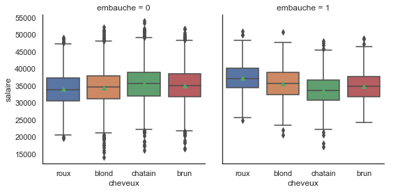

```python
results, anova_tab, pval = quali_quanti(df, 'salaire', 'cheveux')
```

### Dépendances des variables deux à deux :

Il existe probablement des dépendances entre d'autres variables. Il est intéressant de les tester. Il faudra néanmoins émettre une réserve sur la validité du test concernant la variable (âge) qui ne provient pas d'une loi normale. On pourra se référer à la table de résumé sur les dépendances pour une meilleur lecture.

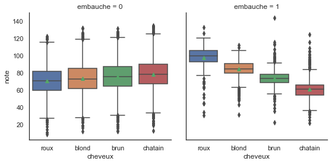

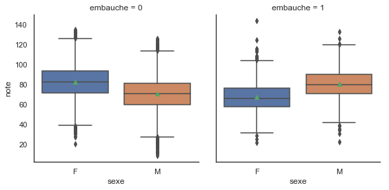

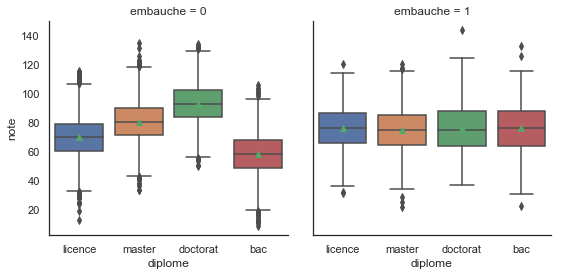

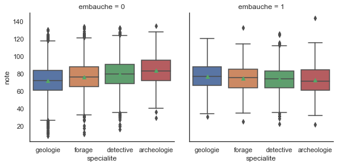

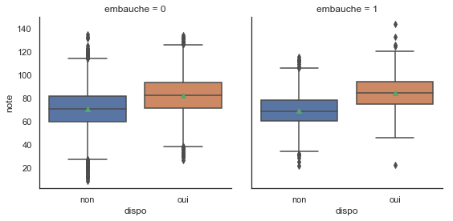

```python
# Boite à moustache note vs toues les catégories :
for cat in categories[:-4]:
    sns.catplot(x=cat, y="note",data=df, kind="box",height=4, aspect=1, col='embauche', showmeans=True)
plt.draw()
```

```python
# Test d'indépendance des variables 2 à 2 :
for cat in categories:
    for quanti in quantitatives:
        results, anova_tab, pval = quali_quanti(df, quanti, cat, showimg=False)
        tab_dep.loc[cat,quanti] = f'{pval:.2f}'
        tab_dep.loc[quanti,cat] = f'{pval:.2f}'
        if pval < 0.05 :
            print(f'{cat} vs {quanti} : pval < 0.05, on rejette l\'hypothèse d\'indépendance')
        else :
            print(f'{cat} vs {quanti} : pval > 0.05, les variables sont indépendantes')
```

```
cheveux vs note : pval < 0.05, on rejette l'hypothèse d'indépendance
cheveux vs salaire : pval < 0.05, on rejette l'hypothèse d'indépendance
cheveux vs age : pval > 0.05, les variables sont indépendantes
cheveux vs exp : pval > 0.05, les variables sont indépendantes
sexe vs note : pval < 0.05, on rejette l'hypothèse d'indépendance
sexe vs salaire : pval < 0.05, on rejette l'hypothèse d'indépendance
sexe vs age : pval > 0.05, les variables sont indépendantes
sexe vs exp : pval > 0.05, les variables sont indépendantes
diplome vs note : pval < 0.05, on rejette l'hypothèse d'indépendance
diplome vs salaire : pval < 0.05, on rejette l'hypothèse d'indépendance
diplome vs age : pval < 0.05, on rejette l'hypothèse d'indépendance
diplome vs exp : pval > 0.05, les variables sont indépendantes
specialite vs note : pval < 0.05, on rejette l'hypothèse d'indépendance
specialite vs salaire : pval < 0.05, on rejette l'hypothèse d'indépendance
specialite vs age : pval > 0.05, les variables sont indépendantes
specialite vs exp : pval > 0.05, les variables sont indépendantes
dispo vs note : pval < 0.05, on rejette l'hypothèse d'indépendance
dispo vs salaire : pval < 0.05, on rejette l'hypothèse d'indépendance
dispo vs age : pval > 0.05, les variables sont indépendantes
dispo vs exp : pval > 0.05, les variables sont indépendantes
mois vs note : pval > 0.05, les variables sont indépendantes
mois vs salaire : pval > 0.05, les variables sont indépendantes
mois vs age : pval > 0.05, les variables sont indépendantes
mois vs exp : pval > 0.05, les variables sont indépendantes
jour vs note : pval > 0.05, les variables sont indépendantes
jour vs salaire : pval > 0.05, les variables sont indépendantes
jour vs age : pval > 0.05, les variables sont indépendantes
jour vs exp : pval > 0.05, les variables sont indépendantes
annee vs note : pval > 0.05, les variables sont indépendantes
annee vs salaire : pval > 0.05, les variables sont indépendantes
annee vs age : pval > 0.05, les variables sont indépendantes
annee vs exp : pval > 0.05, les variables sont indépendantes
embauche vs note : pval > 0.05, les variables sont indépendantes
embauche vs salaire : pval > 0.05, les variables sont indépendantes
embauche vs age : pval > 0.05, les variables sont indépendantes
embauche vs exp : pval > 0.05, les variables sont indépendantes
```

## Résumé sur les dépendances bivariées :

Cette matrice résume les dépendances entre les variables deux à deux en fonction des p-values aux tests d’hypothèses. Les p-values proches de zéro (variables dépendantes) apparaissent en rouge.

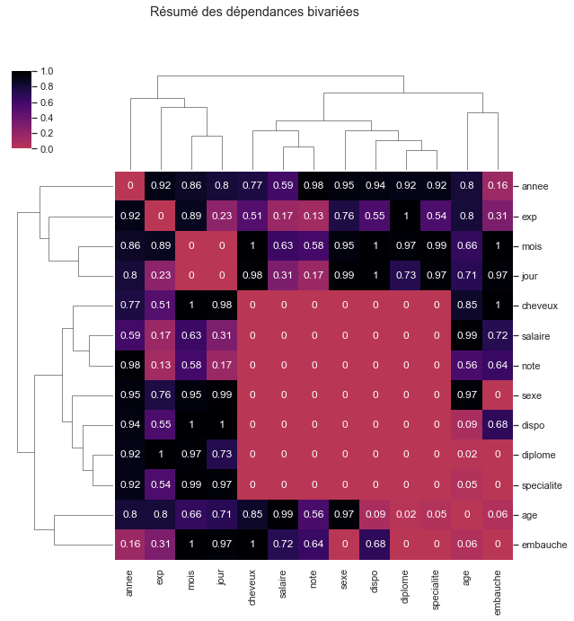

```python
# Résumé des dépendances bivariées :
sns.clustermap(tab_dep.astype(float), annot=True, figsize=(10,10),
               cmap='inferno_r', center=0).fig.suptitle('Résumé des dépendances bivariées')
plt.show()
```

# Traitement des valeurs manquantes

Bien souvent il est nécessaire de traiter les valeurs manquantes (NaN) pour deux raisons principales :

1. Cela peut aider à améliorer le modèle en apportant des informations manquantes.
2. Souvent nous n'avons pas le choix pour pouvoir faire une prédiction sur une observation.

Dans notre cas nous considérons que l'on veut pouvoir prédire toutes les observations d'un jeu de données test sans en supprimer aucune (bien que cela détériore un peu les prédictions dans ce cas précis). C'est une décision arbitraire. Nous observons 1181 valeurs manquantes (ou 999 si on ne considère qu'une seule fois la date) soit près de 5% du jeu de données. Afin de combler ces vides il existe plusieurs méthodes. La plus simple consiste à prendre la médiane de l'ensemble des observations, ou la classe avec la plus grande fréquence dans le cas des données qualitatives, pour remplacer les valeurs manquantes. Néanmoins cette méthode est peu précise. Il est possible de l'améliorer en utilisant les relations de dépendance entre les variables trouvées précédemment. C'est ce qui est utilisé ici. Par exemple, comme nous l'avons vu sur les boites de Tuckey, la médiane des notes des doctorants est aux alentours de 90 tandis que celles des Bacs est plutôt autour de 60, il serait donc plus judicieux de remplacer un NaN d'un doctorant par la note 90 plutôt que par la médiane globale qui est 75. Les fonctions "replace_nan_quanti" et "replace_nan_quali" (cf. notebook) vont chercher toutes les observations similaires à celles ayant une valeur manquante et les remplacer par la médiane commune (ou plus grande fréquence).

```python
def replace_nan_quanti(data, quant_var):
    """
    Cette fonction remplace les NaN
    des variables quantitatives
    """
    index_NaN = list(data[quant_var][data[quant_var].isna()].index)
    for i in index_NaN:
        med = data[quant_var].median()
        pred = data[quant_var][((data['specialite'] == data.iloc[i]["specialite"]) & (
            data['diplome'] == data.iloc[i]["diplome"]) & (
            data['sexe'] == data.iloc[i]["sexe"]) & (
            data['dispo'] == data.iloc[i]["dispo"]) & (
            data['cheveux'] == data.iloc[i]["cheveux"]))]
        if not np.isnan(pred.median()):
            data[quant_var].iloc[i] = pred.median()
        else:
            data[quant_var].iloc[i] = med
    return data

def replace_nan_quali(data, quali_var):
    """
    Cette fonction remplace les NaN
    des variables qualitatives
    """
    categories = ['cheveux', 'sexe', 'diplome', 'specialite', 'dispo']
    feat = quali_var
    categories.remove(feat)
    index_NaN = list(data[feat][data[feat].isna()].index)
    for i in index_NaN:
        pred = data[feat][((data[categories[0]] == data.iloc[i][categories[0]]) & (
            data[categories[1]] == data.iloc[i][categories[1]]) & (
            data[categories[2]] == data.iloc[i][categories[2]]) & (
            data[categories[3]] == data.iloc[i][categories[3]]))]
        if (pred.any()!=np.nan and pred.shape[0]!=0) :
            data.loc[i,[feat]]=pred.value_counts().index[0]
        else:
            data.loc[i,[feat]]=data[feat].value_counts().index[0]
    return data
```

```python
# Calcul du nombre de NaN :
print(df.isna().sum())
print(f'\nTotal NaN : {df.isna().sum().sum()}')
```

```
annee          91
mois           91
jour           91
cheveux       103
age            91
exp            96
salaire        95
sexe          100
diplome       110
specialite     93
note          114
dispo         106
embauche        0
dtype: int64

Total NaN : 1181
```

## Valeurs manquantes les sur données Quantitatives

```python
# Remplacement des NaN sur données quantitatives :
print('Remplacement des NaN sur données quantitatives:\n')
for feat in quantitatives:
    df = replace_nan_quanti(df, feat)
print(df.isna().sum())
```

```
Remplacement des NaN sur données quantitatives:

annee          91
mois           91
jour           91
cheveux       103
age             0
exp             0
salaire         0
sexe          100
diplome       110
specialite     93
note            0
dispo         106
embauche        0
dtype: int64
```

## Valeurs manquantes sur les données Qualitatives

```python
# Ici nous remplacerons simplement les NaN par les medianes des dates
for date in categories[-4:]:
    df[date].fillna(inplace=True, value=df[date].median())

# Ici nous procédons comme avec les variables quantitatives afin de prédire au mieux les NaN
print('Remplacement des NaN sur données quanlitatives:\n')
for cat in categories[:-4]:
    df = replace_nan_quali(df, cat)
print(df.isna().sum())
```

```
Remplacement des NaN sur données quanlitatives:

annee         0
mois          0
jour          0
cheveux       0
age           0
exp           0
salaire       0
sexe          0
diplome       0
specialite    0
note          0
dispo         0
embauche      0
dtype: int64
```

# Importance des features

Avant d'aller plus loins et de créer le modèle que nous conserverons, il est souvent interessant de lancer un Random Forest simple sur les données afin de voir l'importance des variables dans la prédiction des labels. C'est une méthode empirique mais qui donne une bonne intuition.

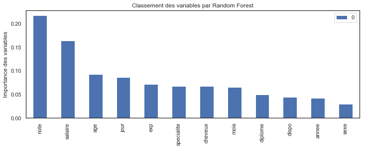

```python
# Encoding des variables nominales en variables quantitatives :
tmp = df.copy()
tmp.dropna(inplace=True)
tmp.sexe = tmp.sexe.map({'F':0,'M':1})
tmp.cheveux = tmp.cheveux.map({'roux':0,'blond':1,'brun':2,'chatain':3})
tmp.diplome = tmp.diplome.map({'bac':0,'licence':1,'master':2,'doctorat':3})
tmp.specialite = tmp.specialite.map({'geologie':0,'forage':1,'detective':2,'archeologie':3})
tmp.dispo = tmp.dispo.map({'non':0,'oui':1})

# Fit un Random Forest sur les données
X = tmp
y = tmp.pop('embauche')
rf = RandomForestClassifier(n_jobs=-1, n_estimators=100, random_state=42)
rf.fit(X,y)

# Importance des variables :
pd.DataFrame(rf.feature_importances_,index=X.columns).sort_values(
    by=0,ascending=False).plot(kind='bar',figsize=(12,4))
plt.ylabel('Importance des variables')
plt.title('Classement des variables par Random Forest')
plt.show()
del tmp
```

# Machine Learning

## Feature Engineering

Afin de faciliter l'entrainement du modèle, il est préférable de lui apporter le plus d'information possible. Pour ce faire nous procédons à plusieurs transformations successives :

1. Ordonnancer (ranking) les catégories nominales en fonction de leur moyenne d'embauche.
2. Les concaténer avec les catégories nominales OneHotEncodés (encodage binaire).
3. Centrer-Réduire les données (standardisation) pour qu'elles soient comparables sur une même échelle de grandeurs.
4. Projection des données centrées-réduites en composantes principales pour maximiser la variance (PCA).
5. Réduction de dimension en fonction de la variance expliquée par les vecteurs propres.

Afin de pouvoir tester notre modèle nous le séparons en deux parties : train 70% / test 30%. Il faut prendre soin de conserver le taux de classes positives dans le train et dans le test, pour cela nous utilisons la méthode "stratify". Par ailleurs, il est nécessaire de séparer le jeu de données avant de centrer-réduire les variables et de faire la PCA, afin que le modèle ne puisse pas apprendre les caractéristiques intrinsèques des variables comme la moyenne et la variance, ce qui aurait pour effet de biaiser positivement les résultats obtenus.

- Dimension du nouveau dataframe après encodage : (20000, 29)
- Dimension du train et du test : X_train: (14000, 28), y_train: (14000,), X_test: (6000, 28), y_test: (6000,)

```python
# Encoding des variables catégorielles en fonction du ranking de leur moyenne d'embauche
# ex: L'année 2013 à une moyenne d'embauche supérieur aux autres, elle aura donc un plus haut rang
columns = ['cheveux','sexe','diplome','specialite','dispo']
data = df.copy()
data.dropna(inplace=True)
for col in columns:
    data[col] = data[col].map(data.groupby(by=col).mean().embauche.sort_values(0).rank(ascending=True, method='max'))

# OneHotEncoding les variables catégorielles
df_oh = pd.get_dummies(data=data, columns=columns, drop_first=False)

# Concaténation des feature encodés et OneHot encodés
df_oh = pd.concat([df_oh, data[columns]], axis=1)
print(f'Dimension du nouveau dataframe après encodage : {df_oh.shape}')
```

```
Dimension du nouveau dataframe après encodage : (20000, 29)
```

## Split du jeu de données

```python
X = df_oh.copy()
y = X.pop(item='embauche')
X_train, X_test, y_train, y_test = train_test_split(X, y, test_size=0.3, random_state=42, stratify = y)
print('Dimension du train et du test :')
print(f'X_train: {X_train.shape}, y_train: {y_train.shape}, X_test: {X_test.shape}, y_test: {y_test.shape}')
```

```
Dimension du train et du test :
X_train: (14000, 28), y_train: (14000,), X_test: (6000, 28), y_test: (6000,)
```

## PCA

- Dimension après PCA : X_train_pca : (14000, 18)

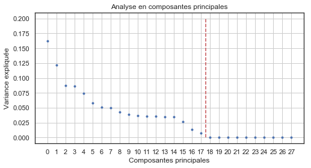

```
Dimension après PCA et réduction : X_train_pca : (14000, 18)
```

```python
# Centrer-réduire les variables avant PCA :
scaler = StandardScaler(with_mean=True)
X_train_std = pd.DataFrame(scaler.fit_transform(X_train))#[['note','salaire']]))
X_test_std = pd.DataFrame(scaler.transform(X_test))#[['note','salaire']]))

# PCA fit sur X_train
pca = PCA(svd_solver='auto')
X_train_pca = pd.DataFrame(pca.fit_transform(X_train_std))
X_test_pca = pd.DataFrame(pca.transform(X_test_std))

# Valeurs propres de la matrice de cov(X_train) triées par ordre décroissant :
v_propres = pd.DataFrame(pca.explained_variance_ratio_)

# plot des valeurs propres
plt.figure(figsize=(8,4))
plt.grid()
plt.plot(v_propres.abs().values,'.')
plt.xticks(np.arange(X_train.shape[1]))
plt.vlines(x=17.5, ymin=0, ymax=0.2, colors='r', linestyles='--')
plt.title('Analyse en composantes principales')
plt.ylabel('Variance expliquée')
plt.xlabel('Composantes principales')
plt.show()

# Réduction de dimension:
pca = PCA(svd_solver='auto', n_components=18)
X_train_pca = pd.DataFrame(pca.fit_transform(X_train_std))
X_test_pca = pd.DataFrame(pca.transform(X_test_std))
print(f'Dimension après PCA et réduction : X_train_pca : {X_train_pca.shape}')
```

## Models Selection

Pour sélectionner le modèle qui sera le plus efficace pour prédire les données du test, nous en testons plusieurs et analysons les scores obtenus. Le score choisi ici est l'aire sous la courbe de Precision-Recall (AUC). J'ai volontairement choisi des classifieurs classiques de la librairie Sklearn pour éviter l'installation de packages lourds comme Keras ou XGBoost et pouvant être longs à entrainer. 10 classifieurs sont testés ici, sans optimisation des paramètres hormis le poids des classes pour les équilibrer. Nous pourrions ne conserver que le meilleur classifeur et l'optimiser. Cependant il est souvent plus efficace d'en sélectionner plusieurs et d'assembler leurs prédictions par un vote à la majorité (ou moyenné) afin d'améliorer la précision, c’est la méthode d’« ensembling ». A l'issue de ce test nous ne conservons que les 5 meilleurs modèles :

- Quadratic Discriminant Analysis (QDA),
- Extra Trees (ET),
- Random Forest (RF),
- Support Vector Machine (SVC),
- Gradient Boosting (GB).

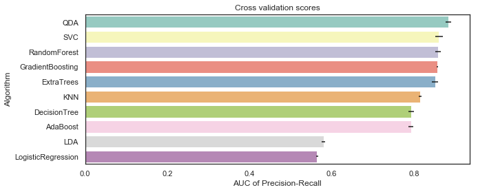

```python
# Choix des Models
random_state = 42
kfold = StratifiedKFold(n_splits=3)
score = make_scorer(prauc_score, needs_proba=True)
w1 = 'balanced'

classifiers = []
classifiers.append(SVC(random_state=random_state, probability=True, class_weight=w1))
classifiers.append(DecisionTreeClassifier(random_state=random_state, class_weight=w1))
classifiers.append(AdaBoostClassifier(DecisionTreeClassifier(random_state=random_state,
                                                             class_weight=w1), random_state=random_state))
classifiers.append(RandomForestClassifier(random_state=random_state, class_weight=w1, n_jobs=-1))
classifiers.append(ExtraTreesClassifier(random_state=random_state, class_weight=w1, n_jobs=-1))
classifiers.append(GradientBoostingClassifier(random_state=random_state))
classifiers.append(KNeighborsClassifier(n_jobs=-1))
classifiers.append(QuadraticDiscriminantAnalysis())
classifiers.append(LogisticRegression(random_state = random_state, class_weight=w1, n_jobs=-1))
classifiers.append(LinearDiscriminantAnalysis())

cv_results = []
cv_pred = []
for clf in classifiers :
    cv_results.append(cross_val_score(estimator=clf, X=X_train_pca.values, y=y_train.values,
                                      scoring=score, cv=kfold, n_jobs=-1))

cv_means = []
cv_std = []
for cv_result in cv_results:
    cv_means.append(cv_result.mean())
    cv_std.append(cv_result.std())

cv_res = pd.DataFrame({"CrossValMeans":cv_means,"CrossValerrors": cv_std,
                       "Algorithm": ["SVC","DecisionTree","AdaBoost","RandomForest","ExtraTrees",
                       "GradientBoosting","KNN","QDA","LogisticRegression","LDA"]})

# Plot ranking modèles :
plt.figure(figsize=(10,4))
g = sns.barplot("CrossValMeans","Algorithm", data=cv_res.sort_values(by='CrossValMeans', ascending=False),
                palette="Set3",orient = "h",**{'xerr':cv_std})
g.set_xlabel("AUC of Precision-Recall")
g = g.set_title("Cross validation scores")
plt.show()
```

## Optimisation des meilleurs modèles

Afin d'améliorer l'efficacité des modèles retenues, nous optimisons leurs hyperparamètres en en testant plusieurs et nous conserverons les meilleurs. Nous faisons cela à l'aide d'un GridSearch Cross-Validation avec un K-fold de 3.

**Cette étape prend un certain temps car il y a de nombreux paramètres à tester. Pour rejouer le GridSearchCV, il suffit de décommenter la cellule. Pour éviter de perdre du temps, vous pouvez passer directement à la cellule d'après qui va charger les modèles déjà entrainés et optimisés.**

```python
# param = []
# param.append({'priors':[None,[1,1],[1,2],[1,3],[2,1],[1,0.3]]}) #param QDA
# param.append({'n_estimators' : [200,400,600,800],'learning_rate': [0.05,0.025,0.015],
#               'max_depth': [4, 6, 8], 'min_samples_leaf': [1,3,10,100]}) #param GradientBoosting
# param.append({'criterion':['gini','entropy'], 'class_weight':['balanced'],
#               'min_samples_split': [2, 3, 10], 'min_samples_leaf': [1, 3, 10]}) #param trees
# param.append({'criterion':['gini','entropy'], 'class_weight':['balanced'],
#               'min_samples_split': [2, 3, 10], 'min_samples_leaf': [1, 3, 10]}) #param trees
# param.append({'C':[1,10,50,100], 'class_weight':['balanced'], 'gamma':[0.01, 0.1, 1]}) #param SVC

# classifiers = []
# classifiers.append(QuadraticDiscriminantAnalysis())
# classifiers.append(GradientBoostingClassifier(random_state=random_state))
# classifiers.append(ExtraTreesClassifier(random_state=random_state, n_jobs=-1, n_estimators=500))
# classifiers.append(RandomForestClassifier(random_state=random_state, n_jobs=-1, n_estimators=500))
# classifiers.append(SVC(random_state=random_state, probability=True))

# clf_name = ['QDA','GradientBoosting','ExtraTrees', 'RandomForest', 'SVC']
# for i, clf in enumerate(classifiers):
#     clf = GridSearchCV(clf, param[i], cv=kfold, return_train_score=False, scoring=score, refit=True, n_jobs=-1)
#     clf.fit(X_train_pca.values, y_train.values.ravel())
# #    filename = f'{clf_name[i]}_best.sav'
# #    joblib.dump(clf.best_estimator_, filename)
```

```python
# Chargement des modèles optimisés:
QDA_best = joblib.load('QDA_best.sav')
GradienBoosting_best = joblib.load('GradientBoosting_best.sav')
ExtraTrees_best = joblib.load('ExtraTrees_best.sav')
RandomForest_best = joblib.load('RandomForest_best.sav')
SVC_best = joblib.load('SVC_best.sav')
model_list = [QDA_best, GradienBoosting_best, ExtraTrees_best, RandomForest_best, SVC_best]
clf_name = ['QDA','GradientBoosting','ExtraTrees', 'RandomForest', 'SVC']
```

## Prédictions

Nous pouvons visualiser ici les résultats des modèles en mesurant l’aire sous la courbe Precision-Recall et nous pouvons observer leur matrice de contingence. Le meilleur score est réalisé par l'Extra Tree avec une aire sous la courbe de 89,4%.

```
QDA : AUC = 0.891
GradientBoosting : AUC = 0.889
ExtraTrees : AUC = 0.894
RandomForest : AUC = 0.892
SVC : AUC = 0.888
```

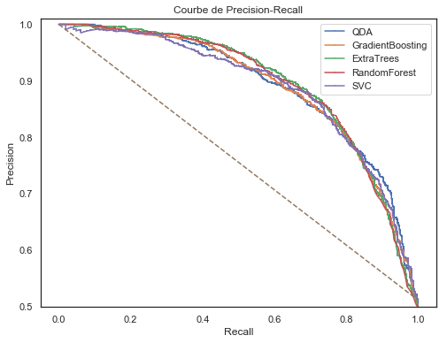

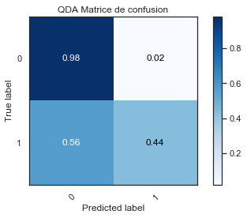

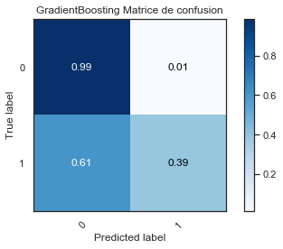

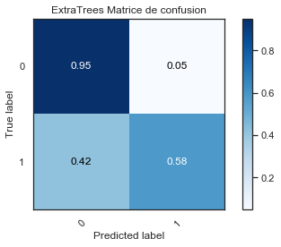

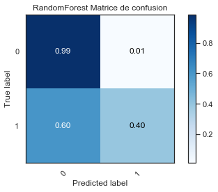

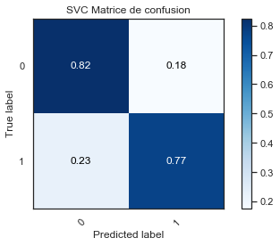

```python
# Print des résultats de prédictions :
plot_prauc(model_list=model_list, X_test=X_test_pca, y_test=y_test, clf_name=clf_name)
for i, model in enumerate(model_list):
    y_pred = model.predict(X_test_pca.values)
    plot_confusion_matrix(y_pred=y_pred, y_true=y_test.values, classes=[0,1], normalize=True, title=f'{clf_name[i]}')
```

### Correlation des modèles

Pour que l'assemblage des modèles soit efficace, il faut que les prédictions soient les plus précises possible mais elles doivent être aussi suffisamment différentes. Pour cela nous pouvons observer la matrice des corrélations des prédictions des modèles. On constate que les prédictions sont fortement corrélées (sauf pour le SVC), mais avec suffisamment de variance pour ne pas être identiques ce qui permettra à l'assemblage d’améliorer les résultats.

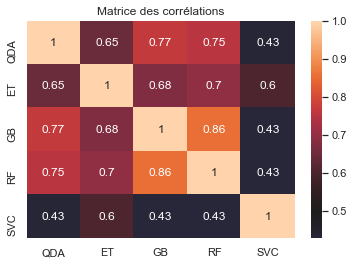

```python
# Corrélations entre les prédictions des différents modèles :
pred_ET = pd.Series(ExtraTrees_best.predict(X_test_pca), name="ET")
pred_GB = pd.Series(GradienBoosting_best.predict(X_test_pca), name="GB")
pred_QDA = pd.Series(QDA_best.predict(X_test_pca), name="QDA")
pred_RF = pd.Series(RandomForest_best.predict(X_test_pca), name="RF")
pred_SVC = pd.Series(SVC_best.predict(X_test_pca), name="SVC")
results = pd.concat([pred_QDA,pred_ET,pred_GB,pred_RF,pred_SVC],axis=1)

ax = plt.axes()
ax.set_title('Matrice des corrélations')
sns.heatmap(results.corr(),annot=True, center=0.5, ax=ax)
plt.show()
```

## Ensembling

L'ensembling consiste à récupérer les prédictions de différents classifieurs et à les assembler. Ici nous faisons cela en moyennant les prédictions « soft » (probabilistes) des précédents modèles. Par ailleurs j’ai dupliqué le classifieur QDA en modifiant les poids afin de créer plus de variance dans les prédictions. Et j’ai accordé plus d’importance à l’Extra Tree lors de l’assemblage car il avait obtenu le meilleur score. Comme nous pouvons le constater, l’ensembling a un effet positif sur les prédictions en améliorant le score d’aire sous la courbe : 90,3% . Nous obtenons en sorti un modèle que j’appelle « pessimiste » car il ne favorise pas spécialement les bons candidats (labels positifs). Ce modèle est néanmoins très efficace dans un cas d’usage particulier qui serait de filtrer les mauvais candidats (labels négatifs). En effet, il classe bien à 98% les vrais négatifs. Ce qui signifie que le risque d’embaucher un mauvais candidat à tort n’est que de 2%, ce qui limite le risque de l’entreprise. Le trade-off cependant est d’éliminer la moitié des bons candidats. Ce modèle serait bien adapté dans le cas d’une entreprise qui aurait beaucoup de candidatures. Nous verrons deux autres modèles par la suite.

```
AUC = 0.9025
QDA : AUC = 0.891
GradientBoosting : AUC = 0.889
ExtraTrees : AUC = 0.894
RandomForest : AUC = 0.892
SVC : AUC = 0.888
Ensembling Classifieur : AUC = 0.903
```

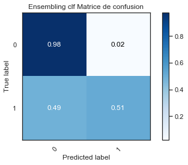

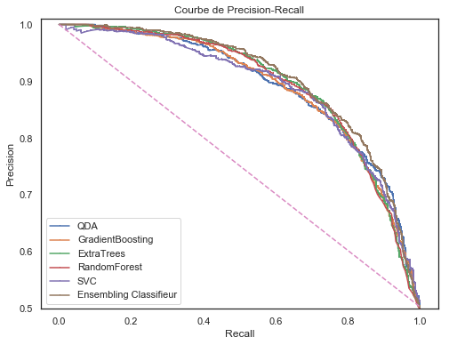

```python
# Ensembling des classifieurs 1 à 7 :
clf1 = ExtraTrees_best
clf2 = RandomForest_best
clf3 = GradienBoosting_best
clf4 = SVC_best
clf5 = QDA_best
clf6 = QuadraticDiscriminantAnalysis(priors=[1,0.3])
clf7 = QuadraticDiscriminantAnalysis(priors=[1,1.2])

ensemble_clf = VotingClassifier(estimators=[('ET',clf1),('RF',clf2),('GB',clf3),('SVC',clf4),('QDA1',clf5),
                                       ('QDA2',clf6), ('QDA3',clf7)],
                                        voting='soft', weights=[2,1,1,1,1,1,1])
ensemble_clf.fit(X_train_pca.values, y_train.values)

# Score du nouveau modèle:
sc = score(X=X_test_pca.values, y=y_test.values, clf=ensemble_clf)
print(f'AUC = {sc:.4f}')

# Matrice de confusion:
ypred = ensemble_clf.predict(X_test_pca.values)
plot_confusion_matrix(y_pred=ypred, y_true=y_test.values, classes=[0,1], normalize=True, title='Ensembling clf')

# Aire sous la courbe :
mod = model_list.copy()
mod.append(ensemble_clf)
name = clf_name.copy()
name.append('Ensembling Classifieur')
plot_prauc(model_list=mod, X_test=X_test_pca, y_test=y_test, clf_name=name)
```

## D'autres modèles pour d’autres usages

Voici 2 autres modèles provenant d’un même classifieur QDA mais entrainé différemment pour des usages différents :

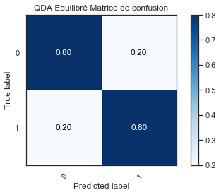

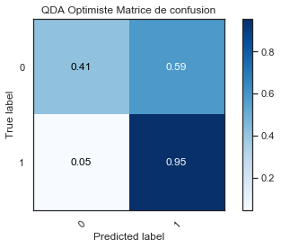

```python
# Matrice de confusion des deux autres modèles "équilibrés" et "optimiste":
priors = [[1,1.2], [0.1,1]]
title = ['QDA Equilibré', 'QDA Optimiste']

for i, p in enumerate(priors):
    qda = QuadraticDiscriminantAnalysis(priors=p)
    qda.fit(X_train_pca.values, y_train.values)
    ypred = qda.predict(X_test_pca.values)
    plot_confusion_matrix(y_pred=ypred, y_true=y_test.values, classes=[0,1], normalize=True, title=title[i])
plt.draw()
```

## Pour aller plus loin

Il est toujours possible d'améliorer les prédictions. Voici quelques pistes :

- Traiter les NaN de façon plus robuste
- Tester plus d'hyper-paramètres
- Améliorer le feature engineering
- Utiliser des méthodes de staking plutôt qu'ensembling
- Utiliser d'autres classifieurs ou réseaux de neuronnes